# Homework 3

Iris Foxfoot

2/20/2022

### Predicting carseats sales using regularized regression methods

```r
#read in data, split into testing and training

set.seed(123)
dat <- model.matrix(Sales~., Carseats)
train = sample(nrow(dat), 30)
x.train = dat[train, ]
y.train = Carseats[train, ]$Sales
# The rest as test data
x.test = dat[-train, ]
y.test = Carseats[-train, ]$Sales
```

#### A. Ridge Regression

(2 pts) Fit a ridge regression model to the training set to predict Sales using all other variables as predictors. Use the built-in cross-validation in cv.glmnet to choose the optimal value of tuning parameter $\lambda$ from the following list of $\lambda$ values using a 5-fold CV. (2 pts) Report the ridge coefficient estimates corresponding to the selected value of $\lambda$.

```r
#list of lambdas
lambda.list.ridge = 1000 * exp(seq(0, log(1e-5), length = 100))

#writing the model
ridge_mod = cv.glmnet(x.train, y.train, alpha = 0, lambda = lambda.list.ridge, folds = 5)

#get best lambda value
bestlam = ridge_mod$lambda.min

#show best lambda value
bestlam
```

```
## [1] 0.04037017
```

```r
#show coefficients using lambda chosen by CV
predict(ridge_mod, type = "coefficients", s = bestlam)[1:13,]
```

```
##     (Intercept)     (Intercept)       CompPrice          Income     Advertising
##    5.6000688973    0.0000000000    0.1099233956    0.0096033470    0.0656698118
##      Population           Price   ShelveLocGood ShelveLocMedium             Age
##    0.0004513543   -0.0964339092    4.4039574899    1.8592944221   -0.0615467949
##       Education        UrbanYes           USYes
##   -0.0857172926    0.6524817233    0.2901733094
```

#### B. Ridge Regression MSE

(2 pts) What is the training MSE for the model corresponding to the optimal value of $\lambda$ selected by the cross-validation above? (2 pts) What is the test MSE for that same model? (1 pts) Comment on your findings.

```r
#show training MSE
ridge.pred.train=predict(ridge_mod, s=bestlam ,newx=x.train)
mean((ridge.pred.train-y.train)^2)
```

```
## [1] 0.5155251
```

```r
#show test MSE
ridge.pred.test=predict(ridge_mod,s=bestlam ,newx=x.test)
mean((ridge.pred.test-y.test)^2)
```

```
## [1] 1.439104
```

The training MSE is lower than the test MSE, indicating that the model may have overfit the data a little bit.

#### C. Lasso Model

(2 pts) Fit a lasso model to the training set to predict Sales using all other variables as predictors. Use the built-in cross-validation in cv.glmnet to choose the optimal value of tuning parameter $\lambda$ from the following list of $\lambda$ values using a 10-fold CV. (2 pts) Report the lasso coefficient estimates corresponding to the selected value of $\lambda$. (2 pts) Are there any coefficients set to zero in the model selected by cross-validation? Comment on your findings.

```r
#getting list of lambdas
lambda.list.lasso = 2 * exp(seq(0, log(1e-4), length = 100))

#building model (alpha set to zero for lasso)
lasso_mod = cv.glmnet(x.train, y.train, alpha = 1, lambda = lambda.list.lasso, folds = 10)

#get best lambda value
bestlam_l = lasso_mod$lambda.min

#show best lambda value
bestlam_l
```

```
## [1] 0.006860939
```

```r
#show coefficients using lambda chosen by CV
predict(lasso_mod, type = "coefficients", s = bestlam_l)[1:13,]
```

```
##     (Intercept)     (Intercept)       CompPrice          Income     Advertising
##    5.2051055063    0.0000000000    0.1170948386    0.0100623605    0.0639737325
##      Population           Price   ShelveLocGood ShelveLocMedium             Age
##    0.0006600398   -0.1016980910    4.5205815904    1.9404400520   -0.0651814135
##       Education        UrbanYes           USYes
##   -0.0806744443    0.6848411562    0.4039457406
```

No, the lasso model did not reduce any predictors’ coefficient estimates to zero.

#### D. Lasso Model MSE

(2 pts) What is the training MSE for the lasso model corresponding to the optimal value of $\lambda$ selected by cross-validation? (2 pts) What is the test MSE for that same model? (1 pts)

```r
#show training MSE
lasso.pred.train=predict(lasso_mod, s=bestlam_l ,newx=x.train)
mean((lasso.pred.train-y.train)^2)
```

```
## [1] 0.5004471
```

```r
#show test MSE
lasso.pred.test=predict(lasso_mod,s=bestlam_l ,newx=x.test)
mean((lasso.pred.test-y.test)^2)
```

```
## [1] 1.507105
```

Again the training error is smaller than the test error, indicating some possible overfitting.

#### E. Compare Ridge and Lasso

(2 pts) Comment on the comparison between ridge and lasso estimates in this application.

Ridge and Lasso produced similar estimates. In this case the lasso model did not reduce any coefficient estimates to zero, but in both cases the CI for population was very small.

### Analyzing Drug Use

```r
#read in the data
drug <- read_csv('drug.csv',
                 col_names=c("ID", "Age", "Gender", "Education", "Country", "Ethnicity", "Nscore", "Escore", "Oscore", "Ascore", "Cscore", "Impulsive", "SS", "Alcohol", "Amphet", "Amyl", "Benzos", "Caff", "Cannabis", "Choc", "Coke", "Crack", "Ecstasy", "Heroin", "Ketamine", "Legalh", "LSD", "Meth", "Mushrooms", "Nicotine", "Semer", "VSA"))
```

#### A. Create new recent_cannabis_use col

(2 pts) Define a new factor response variable recent_cannabis_use which is “Yes” if a person has used cannabis within a year, and “No” otherwise. This can be done by checking if the Cannabis variable is greater than or equal to CL3. Hint: use mutate with the ifelse command. When creating the new factor set levels argument to levels=c(“No”, “Yes”) (in that order).

```r
#creating col for recently used cannabis
drug <- drug %>%
  mutate(recent_cannabis_use = as.factor(
    case_when(Cannabis %in% c("CL3", "CL4", "CL5", "CL6") ~ "Yes", T ~ "No")))

#checking levels
levels(drug$recent_cannabis_use)
```

```
## [1] "No"  "Yes"
```

```r
#they look good
```

#### B. Subset the data

(b). (2 pts) We will only consider a subset of all predictors in subsequent tasks. To do so, we will create a new dataset that includes a subset of the original predictors. In particular, we will focus on all variables between age and SS (inclusively) as well as the new factor recent_cannabis_use you obtained in part (a).

```r
#creating a subset
drug_subset <- drug %>%
  select(Age:SS, recent_cannabis_use)
```

#### C. Split into test and training

(2 pts) Split the dataset you obtained in part (b) into a training data set and a test data set. The training data should include 1100 randomly sampled observation and the test data should include the remaining observations. You will need the training and the test data for subsequent analysis.

```r
#get 1100 rows
drug_train_list = sample(nrow(drug_subset), 1100)

#get data for those rows
drug_train = drug_subset[drug_train_list, ]

#now everything else is test data
drug_test = drug_subset[-drug_train_list, ]
```

#### D. Logistic regression

(4 pts) As a benchmark method, fit a logistic regression to predict recent_cannabis_use using all other predictors in the training data you obtained in (c). Display the results by calling the summary function on the logistic regression object.

```r
#fit a logistic model
logistic <- glm(recent_cannabis_use ~ .,
                data = drug_train,
                family = "binomial")

#show summary of model
summary(logistic)
```

```
##
## Call:
## glm(formula = recent_cannabis_use ~ ., family = "binomial", data = drug_train)
##
## Deviance Residuals:
##     Min       1Q   Median       3Q      Max
## -2.9064  -0.6138   0.1691   0.5673   2.5389
##
## Coefficients:
##             Estimate Std. Error z value Pr(>|z|)
## (Intercept)  1.20658    0.24030   5.021 5.14e-07 ***
## Age         -0.82988    0.10806  -7.680 1.59e-14 ***
## Gender      -0.57332    0.18811  -3.048  0.00231 **
## Education   -0.41514    0.09435  -4.400 1.08e-05 ***
## Country     -1.12124    0.13694  -8.188 2.66e-16 ***
## Ethnicity    1.47419    0.68119   2.164  0.03045 *
## Nscore      -0.16738    0.10330  -1.620  0.10517
## Escore      -0.17053    0.11099  -1.536  0.12444
## Oscore       0.68940    0.10785   6.392 1.64e-10 ***
## Ascore       0.01965    0.09536   0.206  0.83672
## Cscore      -0.38334    0.10343  -3.706  0.00021 ***
## Impulsive   -0.15675    0.12157  -1.289  0.19725
## SS           0.67156    0.13056   5.144 2.69e-07 ***
## ---
## Signif. codes:  0 '***' 0.001 '**' 0.01 '*' 0.05 '.' 0.1 ' ' 1
##
## (Dispersion parameter for binomial family taken to be 1)
##
##     Null deviance: 1519.10  on 1099  degrees of freedom
## Residual deviance:  884.16  on 1087  degrees of freedom
## AIC: 910.16
##
## Number of Fisher Scoring iterations: 5
```

```r
#get probabilities (for later use in part L)
log_prob_test = predict(logistic, drug_test, type = "response")

#get prediction
log_pred = prediction(log_prob_test, drug_test$recent_cannabis_use)
```

#### E. Single tree

(e). (2 pts) Construct a single decision tree to predict recent_cannabis_use using all other predictors in the training data.

```r
single_tree <- tree(recent_cannabis_use ~ .,
                data = drug_train)

summary(single_tree)
```

```
##
## Classification tree:
## tree(formula = recent_cannabis_use ~ ., data = drug_train)
## Variables actually used in tree construction:
## [1] "Country"   "Age"       "Oscore"    "SS"        "Education" "Cscore"
## Number of terminal nodes:  9
## Residual mean deviance:  0.8696 = 948.8 / 1091
## Misclassification error rate: 0.1873 = 206 / 1100
```

#### F. Cross validated single tree

(2 pts) Use 5-fold cross-validation to select the best size of a tree which minimizes the cross-validation estimate of the test error rate. Use the function cv.tree, and set the argument FUN=prune.misclass. If multiple trees have the same minimum cross validated error rate, set best_size to the smallest tree size with that minimum rate. (2 pts) Report the best size you obtained.

```r
#cross validate tree
cv_tree = cv.tree(single_tree, FUN=prune.misclass, K=5)

#show best size
best_size = min(cv_tree$size[cv_tree$dev==min(cv_tree$dev)])
best_size
```

```
## [1] 4
```

#### G. Prune and plot tree

(g). (2 pts) Prune the tree to the best size selected in the previous part and plot the tree using the draw.tree function from the maptree package (see Lab 6). Set nodeinfo=TRUE. (2 pts) Which variable is split first in this decision tree?

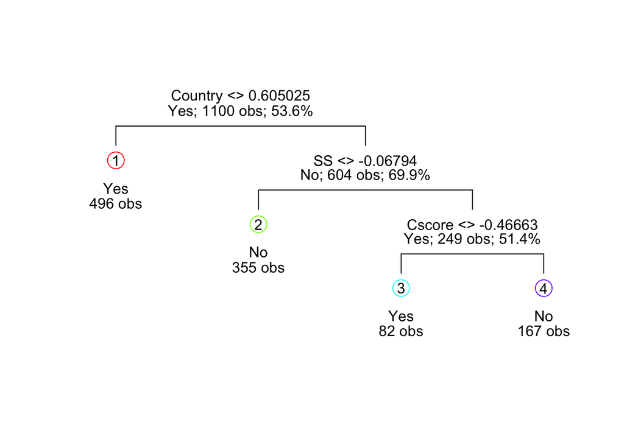

```r
#prune the tree to the best size
pruned_tree = prune.misclass(single_tree, best = best_size)

#plot it
maptree::draw.tree(pruned_tree, nodeinfo=TRUE)
```

The first split is on the variable `Country`

#### H. Confusion matrix

(2 pts) Compute and print the confusion matrix for the test data using the function table. (Hint: Recall that the table function takes in two arguments: the first argument is the true classes, and the second argument is the predicted classes. To generate the predicted classes for the test data, set type=“class” in the predict function.) (2 pts) Calculate the true positive rate (TPR) and false positive rate (FPR) for the confusion matrix. Show how you arrived at your answer.

```r
#make predictions for test data
yhat_drug = predict(pruned_tree, newdata = drug_test, type = "class")

#make confusion matrix
pt_error = table(pred = yhat_drug, truth = drug_test$recent_cannabis_use)

#show confusion matrix
pt_error
```

```
##      truth
## pred   No Yes
##   No  292  90
##   Yes  84 319
```

```r
#calc the true positive (number of observations predicted yes and with a true values of yes divided by total number of observations in test data set)
true_p = as.data.frame(pt_error) %>%
  filter(pred == "Yes", truth == "Yes")

true_p$Freq/nrow(drug_test)
```

```
## [1] 0.4063694
```

```r
#calc the false positive rate (number of observations predicted yes but have true values of no divided by total number of observations in test data set)
false_p = as.data.frame(pt_error) %>%
  filter(pred == "Yes", truth == "No")

false_p$Freq/nrow(drug_test)
```

```
## [1] 0.1070064
```

#### I. Boosted Tree

(2 pts) Fit a boosting model to the training set with recent_cannabis_use as the response and the other variables as predictors. Use the gbm to fit a 1,000 tree boosted model and set the shrinkage value of 0.01. (2 pts) Which predictors appear to be the most important (Hint: use the summary function)?

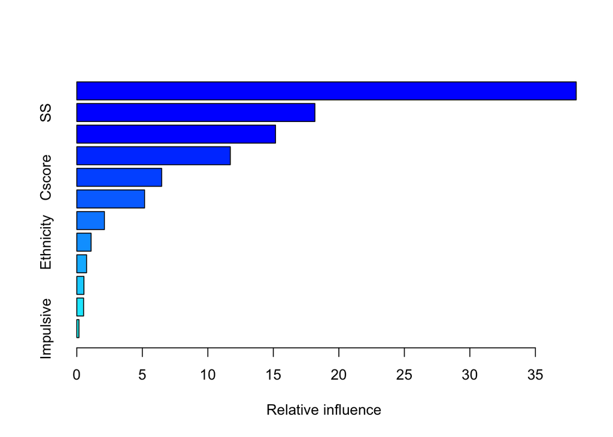

```
##                 var    rel.inf
## Country     Country 38.1168402
## SS               SS 18.1732506
## Age             Age 15.1665607
## Oscore       Oscore 11.7145685
## Cscore       Cscore  6.4784500
## Education Education  5.1750311
## Gender       Gender  2.1093916
## Ethnicity Ethnicity  1.0897060
## Escore       Escore  0.7461611
## Ascore       Ascore  0.5444972
## Nscore       Nscore  0.5201427
## Impulsive Impulsive  0.1654004
```

```r
#convert depdendent var into 0 or 1 format for boosted tree model
drug_train_boosted <- drug_train %>%
  mutate(recent_cannabis_use = case_when(recent_cannabis_use == "No" ~ 0, T ~ 1))

#run the model
boosted_tree <- gbm(recent_cannabis_use ~.,
                    distribution = "bernoulli",
                    data = drug_train_boosted,
                    n.trees = 1000,
                    shrinkage = 0.01)

#summarise the model
summary(boosted_tree)
```

Country, SS, and Age appear to be important predictors of cannabis use in this dataset.

#### J. Random Forest

(2 pts) Now fit a random forest model to the same training set from the previous problem. Set importance=TRUE but use the default parameter values for all other inputs to the randomForest function. Print the random forest object returned by the random forest function. (1 pts) What is the out-of-bag estimate of error? (1 pts) How many variables were randomly considered at each split in the trees? (1 pts) How many trees were used to fit the data? Look at the variable importance. (1 pts) Is the order of important variables similar for both boosting and random forest models?

```r
#run the model
random_forest <- randomForest(recent_cannabis_use ~.,
                              data = drug_train,
                              importance = T)

#look at model results
random_forest
```

```
##
## Call:
##  randomForest(formula = recent_cannabis_use ~ ., data = drug_train,      importance = T)
##                Type of random forest: classification
##                      Number of trees: 500
## No. of variables tried at each split: 3
##
##         OOB estimate of  error rate: 19.27%
## Confusion matrix:
##      No Yes class.error
## No  393 117   0.2294118
## Yes  95 495   0.1610169
```

```r
#look at order of importance
importance(random_forest)
```

```
##                   No        Yes MeanDecreaseAccuracy MeanDecreaseGini
## Age       27.5171651 23.7945833            34.563083         55.10646
## Gender    14.4130644  5.4179271            14.016379         15.44523
## Education 15.0609594  6.3630051            14.953974         36.37046
## Country   61.0089614 30.0930098            62.787568         96.57290
## Ethnicity  0.7277623  7.6678716             6.081136          5.35832
## Nscore     7.6488553 -0.3880484             5.555851         39.82936
## Escore     5.7854328  1.3260179             5.007910         37.25037
## Oscore    24.0976588 21.8301727            32.166274         66.99454
## Ascore     1.1814737  3.9516414             3.569681         38.07201
## Cscore    18.3126693 10.8910494            20.194858         51.00932
## Impulsive 16.1344199 -1.4150559            13.231942         32.46541
## SS        35.1382721 19.7878278            41.203482         70.41398
```

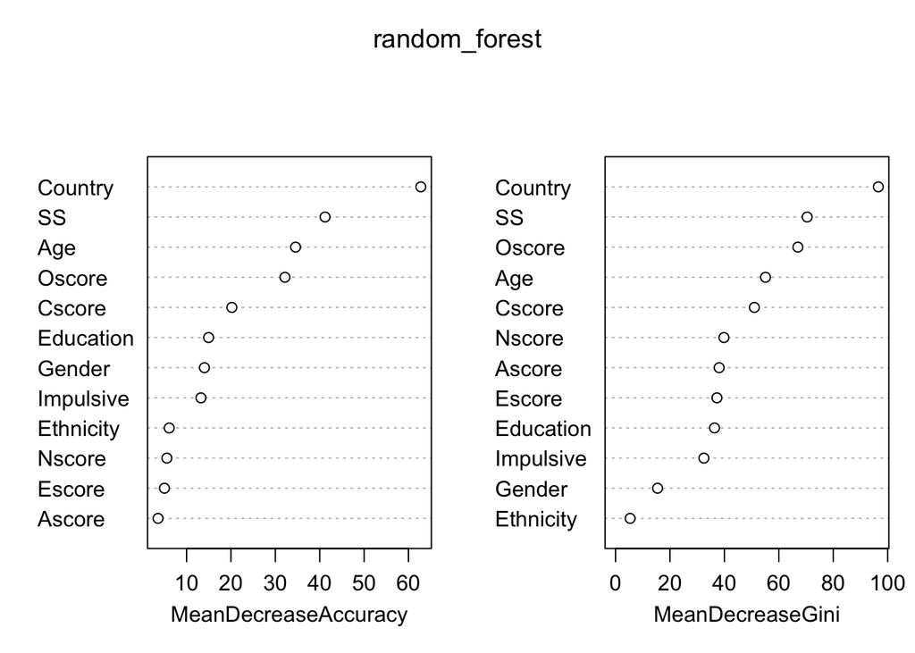

```r
#plot importance
varImpPlot(random_forest)
```

#### K. Confusion Matrix for Boosted and RF Models

(2 pts) Use both models to predict the response on the test data with a certain threshold. Predict that a person will have recent_cannabis_use = Yes if the predicted probability of recent_cannabis_use is greater than or equal to 20%. (2 pts) Print the confusion matrix for both the boosting and random forest models. (2 pts) In the random forest model, what fraction of the people predicted to use cannabis recently do in fact use cannabis recently? (Hint: use the predict function with type=“prob” for random forests and type=“resonpse” for the boosting algorithm. See Lab 7).

```r
#prediction of test data based on random forest model
yhat.rf = predict(random_forest,
                  newdata = drug_test,
                  type = "prob")

#create column that indicates "yes" if prob exceeds 20% and "no" if it is less than 20%
yhat.rf <- as.data.frame(yhat.rf) %>%
  mutate(recent_cannabis_use = case_when(Yes >= 0.2 ~ "Yes", T ~ "No"))

#confusion matrix on random forest predictions
rf.err = table(pred = yhat.rf$recent_cannabis_use,
               truth = drug_test$recent_cannabis_use)

#print confusion matrix
rf.err
```

```
##      truth
## pred   No Yes
##   No  179  24
##   Yes 197 385
```

```r
#calc the true positive rate
true_p.rf = as.data.frame(rf.err) %>%
  filter(pred == "Yes", truth == "Yes")

#true positive rate
true_p.rf$Freq/nrow(drug_test)
```

```
## [1] 0.4904459
```

```r
#prediction of test data based on boosted tree model
yhat.boosted = predict(boosted_tree,
                       newdata = drug_test,
                       type = "response")
```

```
## Using 1000 trees...
```

```r
yhat.boosted <- as.data.frame(yhat.boosted) %>%
  mutate(recent_cannabis_use = case_when(yhat.boosted >= 0.2 ~ "Yes",
                                         T ~ "No"))


#confusion matrix on boosted tree predictions
boost.err = table(pred = yhat.boosted$recent_cannabis_use,
                  truth = drug_test$recent_cannabis_use)

#print confusion matrix
boost.err
```

```
##      truth
## pred   No Yes
##   No  185  20
##   Yes 191 389
```

The random forest model has a true positive rate of 0.49. The fraction of correct predictions to correct answers is 385/785.

#### L. ROC curves

(4 pts) Plot the ROC curves for the logistic regression fit, the best pruned decision tree, the random forest, and the boosting trees that you obtained in previous parts. The ROC curves should be computed using the test data. (Hint: recall in Lab 3 we covered how to plot ROC curves for classification problems.)

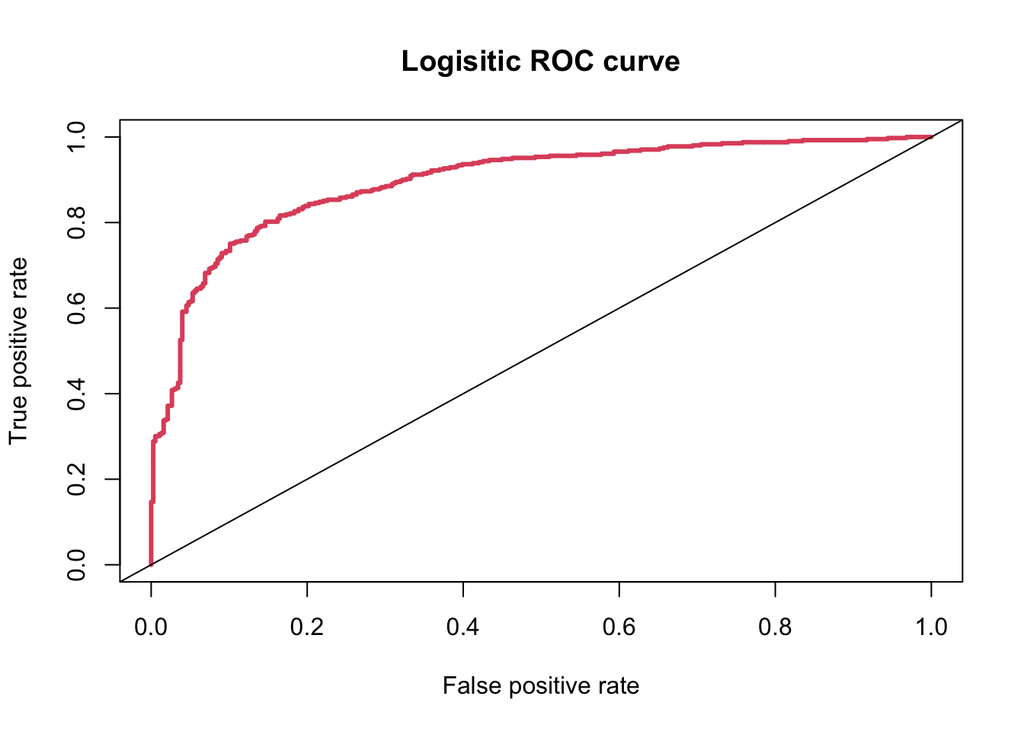

```r
#get performance of logistic regresision
log_perf <- performance(log_pred, measure = "tpr", x.measure = "fpr")

#plot ROC curve
plot(log_perf, col=2, lwd=3, main="Logisitic ROC curve")
abline(0,1)
```

```r
# Calculate AUC
auc = performance(log_pred, "auc")@y.values
auc
```

```
## [[1]]
## [1] 0.8960685
```

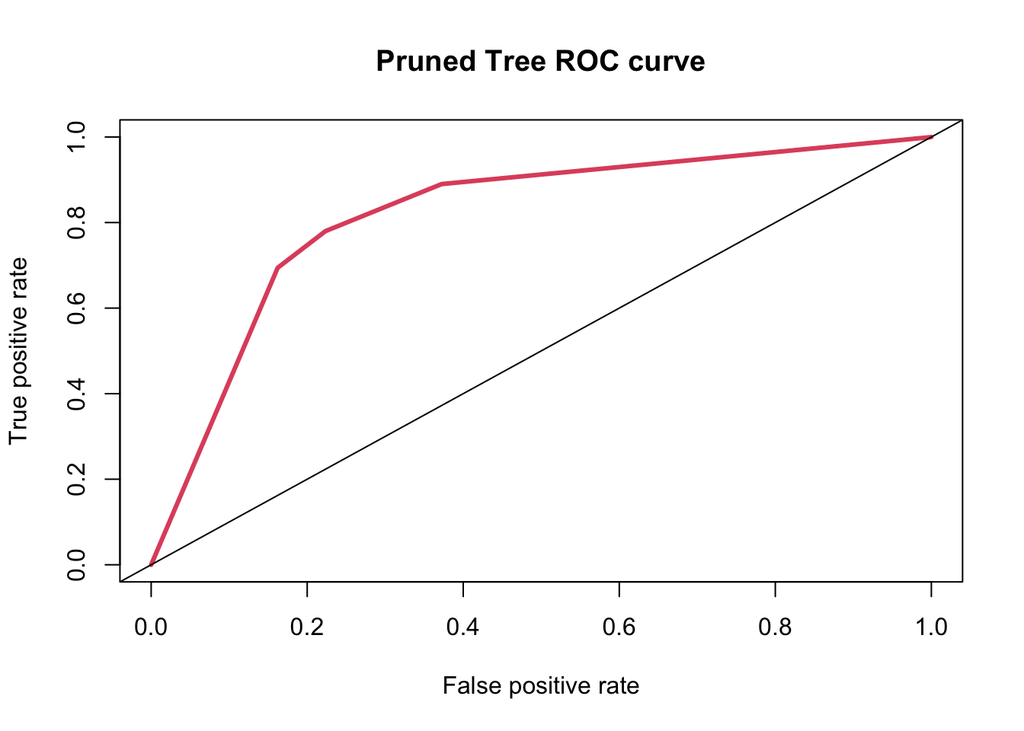

```r
#single tree

#make list of predictions
tree_predictions <- predict(pruned_tree, drug_test, type = "vector") %>%
  as.data.frame()

#prediction
tree_pred <- prediction(tree_predictions$Yes, drug_test$recent_cannabis_use)

#performance
tree_perf = performance(tree_pred, measure="tpr", x.measure="fpr")

#roc curve
plot(tree_perf, col=2, lwd=3, main="Pruned Tree ROC curve")
abline(0,1)
```

```r
#Calculate AUC
auc = performance(tree_pred, "auc")@y.values
auc
```

```
## [[1]]
## [1] 0.8189051
```

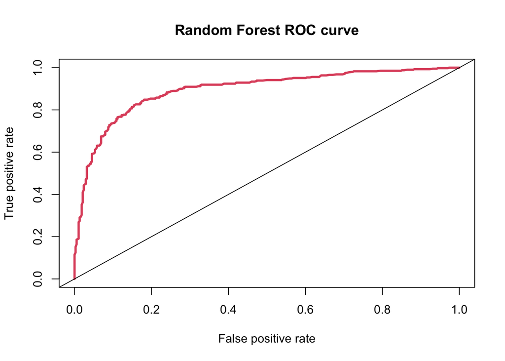

```r
#random forest (in this case we have calculated predictions above)
rf_pred <- prediction(as.data.frame(yhat.rf)$Yes, drug_test$recent_cannabis_use)

#performance
rf_perf = performance(rf_pred, measure="tpr", x.measure="fpr")

#roc curve
plot(rf_perf, col=2, lwd=3, main="Random Forest ROC curve")
abline(0,1)
```

```r
#Calculate AUC
auc = performance(rf_pred, "auc")@y.values
auc
```

```
## [[1]]
## [1] 0.8945632
```

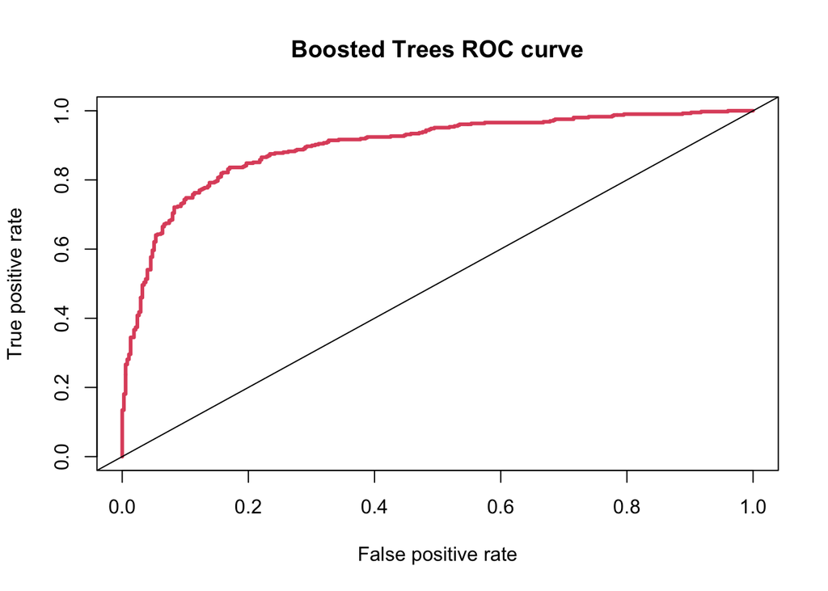

```r
#boosted tree (in this case we have calculated predictions above)

#organize predictions of boosted tree model
boost_pred <- prediction(yhat.boosted$yhat.boosted, drug_test$recent_cannabis_use)

#performance
boosted_perf = performance(boost_pred, measure="tpr", x.measure="fpr")

#roc curve
plot(boosted_perf, col=2, lwd=3, main="Boosted Trees ROC curve")
abline(0,1)
```

```r
#Calculate AUC
auc = performance(boost_pred, "auc")@y.values
auc
```

```
## [[1]]
## [1] 0.8962506
```

#### M. AUC values

(4 pts) Compute the AUC for the four models and print them. Which model has larger AUC?

The boosted tree model has the highest AUC value, followed by the logistic regression model.

### Bootstrapping

In the 2020-2021 season, Stephen Curry, an NBA basketball player, had made 337 out of 801 three point shot attempts (42.1%). Use bootstrap resampling on a sequence of 337 1’s (makes) and 464 0’s (misses). For each bootstrap sample compute and save the sample mean (e.g. bootstrap FG% for the player). Use 1000 bootstrap samples to plot a histogram of those values. Compute the 99% bootstrap confidence interval for Stephen Curry’s “true” end-of-season FG% using the quantile function in R. Print the endpoints of this interval.

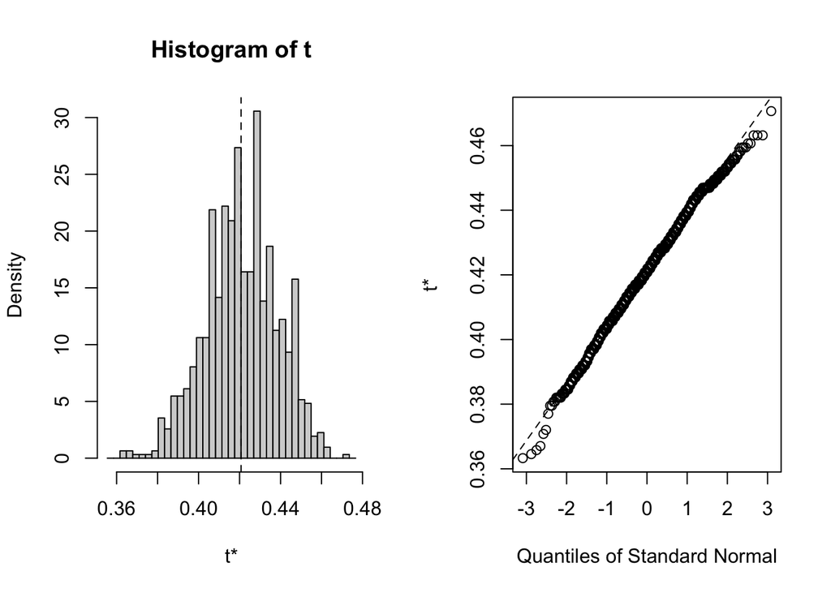

```r
#load needed package
library(boot)

#create vector to sample from based on Curry's shot record
score_vec <- c(rep(1, 337), rep(0, 464))

#make function
mean_fun <- function(data, idx)
{
  df <- data[idx]
  return(mean(df))
}

#bootstrap
bootstrapped <- boot(score_vec, mean_fun, R = 1000)

#plot it
plot(bootstrapped)
```

```r
#Compute the 99% bootstrap confidence interval for Stephen Curry’s “true” end-of-season FG%
boot.ci(bootstrapped, conf=0.99, type="bca")
```

```
## BOOTSTRAP CONFIDENCE INTERVAL CALCULATIONS
## Based on 1000 bootstrap replicates
##
## CALL :
## boot.ci(boot.out = bootstrapped, conf = 0.99, type = "bca")
##
## Intervals :
## Level       BCa
## 99%   ( 0.3666,  0.4595 )
## Calculations and Intervals on Original Scale
## Some BCa intervals may be unstable
```